# Modeling a detection and treatment bundle for postpartum hemorrhage

Christopher Troeger, Stefanie Robinson, Laura Lamberti

October 18, 2024

## Motivation & research in context

Excessive bleeding following childbirth, often called postpartum hemorrhage (PPH), is one of the leading causes of maternal death.

Postpartum hemorrhage has several known risk factors like anemia and location of childbirth.<sup>1,2</sup> Women who have anemia or deliver outside of health facilities are more likely to bleed excessively and to die from blood loss.

Sadly, it is far too common that women with PPH do not receive treatment. This is due in part to a failure to diagnose excessive bleeding. Subjective measurements of blood loss, like visual or estimated, often fail to identify women with PPH. A much more reliable way is to collect and measure blood lost in childbirth. Clinically, PPH occurs when more than 500 mL of blood is lost and severe PPH occurs when more than 1000 mL is lost. Despite effective immediate treatment options that can be delivered in most healthcare facilities, coverage of these treatments is far too low.

Recently, a clinical trial found that a simple package to identify and treat PPH led to a 60% reduction in severe PPH and death.<sup>3</sup> The EMOTIVE bundle, as it is known, consists of objective measurement of blood loss followed by immediate treatment including uterotonics and IV fluids.

We wanted to better understand the potential impact of identifying and treating women with PPH and how this might reduce maternal mortality in Africa and South Asia so we built an epidemiological model to learn more.

## Key findings

### 1. Postpartum hemorrhage is forecasted to be a major cause of maternal death in South Asia and sub-Saharan Africa to 2040

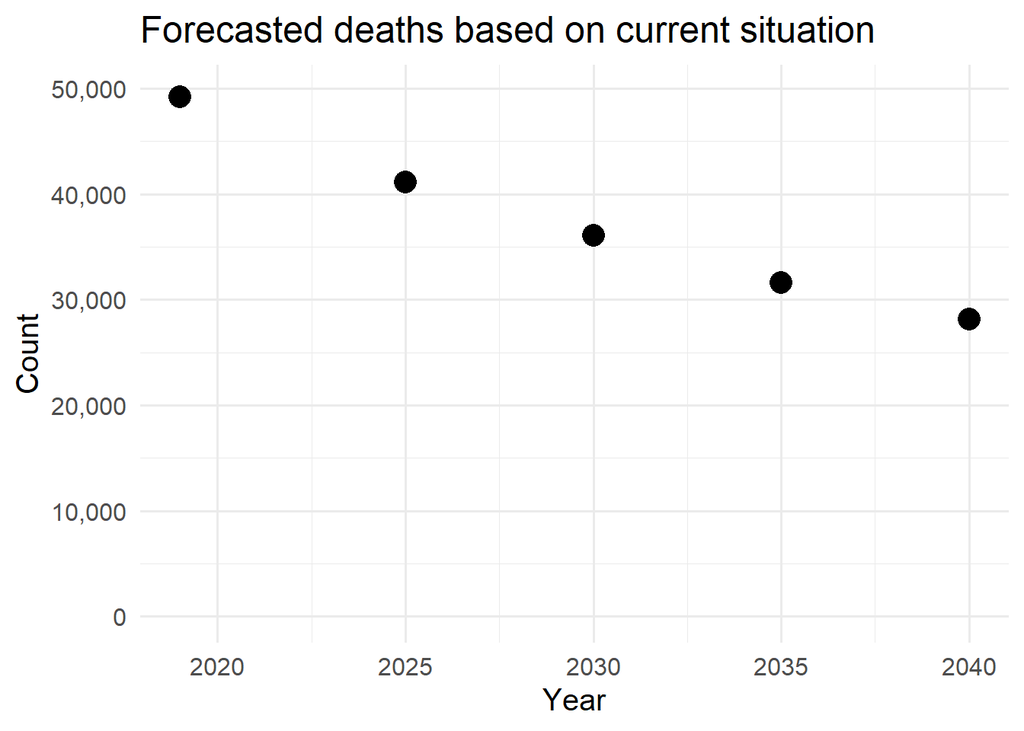

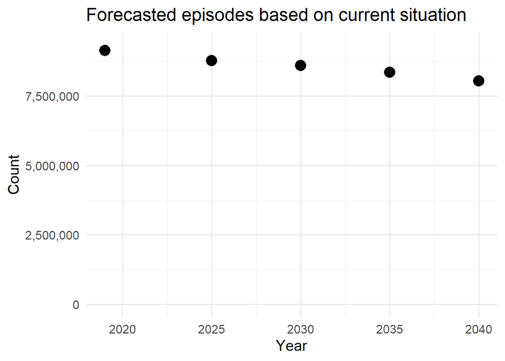